# SI 618 Homework 5 - Natural Language Processing

### The total score for this assignment will be 100 points, consisting of:

- 10 pt: Overall quality of spelling, grammar, punctuation, etc. of written sentences.
- 10 pt: Code is written in [PEP 8](https://www.python.org/dev/peps/pep-0008/) style.
- 80 pt: Homework questions. Questions 1 through 6 are worth 10 points each; Question 7 is worth 20 points.

Version 2024.02.20.CT

## Background

https://www.kaggle.com/headsortails/us-election-2020-presidential-debates

The US 2020 election saw the incumbent Republican president Donald Trump facing off against his Democrat challenger Joe Biden. Both candidates agreed to debate their political stances in the lead-up to the vote on November 3rd.

The 1st debate took place on September 29th at Case Western Reserve University in Cleveland, Ohio. It was moderated by Fox News anchor Chris Wallace.

After Donald Trump tested positive for Covid-19 after his first debate and subsequently recovered, the 2nd presidential debate was initially converted into a virtual event. However, Trump declined to participate in a virtual debate and the event was transformed into a (socially distanced) town hall with Joe Biden alone. This event was moderated by George Stephanopoulos on the ABC network and took place on October 15th. Donald Trump then decided to hold a town hall of his own, which took place at the same day and time as the Biden town hall and was aired on NBC. This event was moderated by Savannah Guthrie.

The actual 2nd, and final, presidential debate between Biden and Trump took place on October 22nd at Belmont University, Nashville, Tennessee and was moderated by NBC News' Kristen Welker. This debate implemented stricter conditions on the candidates' speaking times to limit the frequent interruptions that had characterised the 1st debate.

The goal of this homework assignment is to investigate the transcripts of those events.

The data files are available via https://github.com/umsi-data-science/data/tree/main/us_election_2020. Note that each file is available in two formats: CSV and TXT. You can work from either format -- the content of the corresponding CSV and TXT files is the same.

You can either use the correct URLs to the Raw version of the data files like we've done with other data files in the course so far, you can clone the repo if you're comfortable with `git`, or you can click on each file and then view the "Raw" format and download the resulting file. You do not need the us_election_2020_vice_presidential_debate files as we are only concerned with the presidential debates and town halls for this assignment.

Note that *you* will need to make decisions about how you proceed with the analysis. For example, you will need to decide whether you include or omit stopwords, whether you stem or lemmatize words before analysis, and how you handle weird situations.

You will need to decide when to exclude speech from the moderators and when to include it (note that in most cases, the assignment asks about the candidates, which means Trump and Biden and not the moderators).

Please fill in your uniqname in the next code cell:

```python
MY_UNIQNAME = "qirong"
```

Answer each of the questions below. You are encouraged to use as many code and markdown cells as you need for each question.

We **strongly** suggest running all cells from top to bottom before you submit your notebook.

## Q1.

### How many words did each candidate (Trump & Biden) use in each debate?

```python
# your code here...]
import pandas as pd
import nltk
from nltk.tokenize import word_tokenize
from nltk.corpus import stopwords
from nltk.stem import WordNetLemmatizer
import string
import spacy
from collections import Counter
from nltk import pos_tag  # Importing pos_tag

# Load the transcripts of each debate
debate1_transcript = pd.read_csv('us_election_2020_1st_presidential_debate.csv')
debate2_transcript = pd.read_csv('us_election_2020_2nd_presidential_debate.csv')
```

```python
nltk.download('punkt')
nltk.download('stopwords')
nltk.download('averaged_perceptron_tagger')
nltk.download('wordnet')
!python -m spacy download en_core_web_sm
```

```
     ━━━━━━━━━━━━━━━━━━━━━━━━━━━━━━━━━━━━━━━━ 12.8/12.8 MB 25.4 MB/s eta 0:00:0000:0100:01

✔ Download and installation successful
You can now load the package via spacy.load('en_core_web_sm')
```

### Removing contractions from the text and performing tokenization of the text.

### Remove punctuation from the text.

### Remove stopwords from the text

### Lemmatization of the text

```python
# Load Spacy model
nlp = spacy.load('en_core_web_sm')

# Function to preprocess text
def preprocess_text(text):
    # Tokenize text
    tokens = word_tokenize(text)
    # Remove punctuation
    tokens = [word for word in tokens if word.isalnum()]
    # Remove stopwords
    stop_words = set(stopwords.words('english'))
    tokens = [word for word in tokens if word not in stop_words]
    # Lemmatization with POS tagging
    lemmatizer = WordNetLemmatizer()
    lemmatized_tokens = []
    for word, tag in pos_tag(tokens):
        pos = tag[0].lower()
        pos = pos if pos in ['a', 'r', 'n', 'v'] else None
        if not pos:
            lemma = word
        else:
            lemma = lemmatizer.lemmatize(word, pos)
        lemmatized_tokens.append(lemma)
    return lemmatized_tokens
```

```python
# Function to count words for each candidate in a debate with specific candidate names
def count_words(debate_transcript, candidate_names_debate1, candidate_names_debate2, debate_number):
    word_counts = {}
    if debate_number == 1:
        candidate_names = candidate_names_debate1
    else:
        candidate_names = candidate_names_debate2
    for candidate in candidate_names:
        candidate_text = ' '.join(debate_transcript[debate_transcript['speaker'].str.contains(candidate, case=False)]['text'])
        processed_text = preprocess_text(candidate_text)
        word_counts[candidate] = len(processed_text)
    return word_counts

# Candidate names for debate 1 and debate 2
candidate_names_debate1 = ['President Donald J. Trump', 'Vice President Joe Biden']
candidate_names_debate2 = ['Donald Trump', 'Joe Biden']

# Count words for each candidate in each debate with specific names
debate1_word_counts = count_words(debate1_transcript, candidate_names_debate1, candidate_names_debate2, 1)
debate2_word_counts = count_words(debate2_transcript, candidate_names_debate1, candidate_names_debate2, 2)

print("Debate 1 Word Counts:", debate1_word_counts)
print("Debate 2 Word Counts:", debate2_word_counts)
```

```
Debate 1 Word Counts: {'President Donald J. Trump': 3852, 'Vice President Joe Biden': 3352}
Debate 2 Word Counts: {'Donald Trump': 4065, 'Joe Biden': 3697}
```

In the first debate, Trump speak 3852 words and Biden speak 3352 words. In the second debate, Trump speak 4065 words and Biden speak 3697 words. Trump speak more words in both debates than Biden.

## 2. How many turns speaking did each candidate (Trump & Biden) take during each of the debates?

A "turn" is an uninterrupted period of speech. For example, consider the following exchange:

> Chris: Big data is really interesting.

> Colleague: Actually, it's a bit boring.

> Chris: Really? Why would you say that?

> Colleague: Your choice of tools is really limited.

> Colleague: I mean, you're basically stuck with Spark, right?

> Chris: Yeah, but Spark provides most of the functionality you need to do really cool data science work.

In it, Chris had 3 turns, while his colleague had 2.

You answer should include a dataframe that looks like (with the real values instead of $__$:

| Candidate | First Debate | Second Debate |
| --- | --- | --- |
| Trump | __ | __ |
| Biden | __ | __ |

```python
# your code here...
# Function to count speaking turns
def count_speaking_turns(transcript, candidate_names):
    speaking_turns = {candidate: 0 for candidate in candidate_names}

    # Current speaker initialization
    current_speaker = None

    for index, row in transcript.iterrows():
        speaker = row['speaker']
        if speaker not in candidate_names:
            continue  # Skip if speaker is not one of the candidates
        if speaker != current_speaker:
            speaking_turns[speaker] += 1
            current_speaker = speaker

    return speaking_turns
```

```python
# your code here...

# Count speaking turns for each candidate in each debate
debate1_turns = count_speaking_turns(debate1_transcript, candidate_names_debate1)
debate2_turns = count_speaking_turns(debate2_transcript, candidate_names_debate2)

# Creating DataFrame to display the results
results_df = pd.DataFrame({
    'First Debate': [[None],debate1_turns[candidate_names_debate1[0]], debate1_turns[candidate_names_debate1[1]]],
    'Second Debate': [[None],debate2_turns[candidate_names_debate2[0]], debate2_turns[candidate_names_debate2[1]]]
}, index=['Candidate','Trump', 'Biden'])

print(results_df)
```

```
          First Debate Second Debate
Candidate       [None]        [None]
Trump              201            92
Biden              201            92
```

In the first debate, both Trump and Biden had 201 turns. In the second debate, both Trump and Biden had 92 turns. This indicates that in both debates, Trump and Biden had a similar number of uninterrupted periods of speech, with each candidate taking roughly the same number of turns. This information provides insight into the balance of speaking opportunities between the two candidates during the debates.

## 3. How many different nouns did each candidate (Trump & Biden) use in each of the debates?

Present your results using a visualization (hint: a simple bar chart, with one bar per candidate per debate would be a good choice; you should decide whether you want to somehow stack or group the bars in your bar chart, or just leave them all side by side). You do not need to report **which** nouns were used. Provide a written interpretation of your visualization.

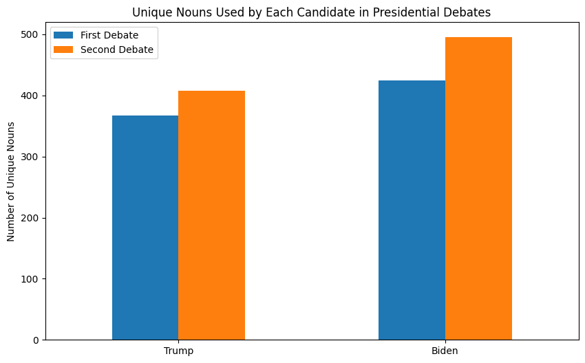

```python
import matplotlib.pyplot as plt
# your code here...
# extract unique nouns from a text
def extract_unique_nouns(text):
    words = word_tokenize(text)
    words = [word for word in words if word.isalpha()]  # Remove punctuation
    stop_words = set(stopwords.words('english'))
    words = [word for word in words if word not in stop_words]  # Remove stopwords
    tagged = pos_tag(words)
    # Extract unique nouns (NN for singular noun, NNS for plural noun)
    nouns = {word for word, tag in tagged if tag in ["NN", "NNS"]}
    return nouns

# Candidate names
debate1_candidate_names = ['President Donald J. Trump', 'Vice President Joe Biden']
debate2_candidate_names = ['Donald Trump', 'Joe Biden']

# Count unique nouns for each candidate in each debate
def count_nouns(transcript, candidate_names):
    noun_counts = {}
    for candidate in candidate_names:
        candidate_text = ' '.join(transcript[transcript['speaker'].str.contains(candidate, case=False, regex=False)]['text'])
        unique_nouns = extract_unique_nouns(candidate_text)
        noun_counts[candidate] = len(unique_nouns)
    return noun_counts

noun_counts_debate1 = count_nouns(debate1_transcript, debate1_candidate_names)
noun_counts_debate2 = count_nouns(debate2_transcript, debate2_candidate_names)

# Prepare data for visualization
data = {
    'First Debate': [noun_counts_debate1[debate1_candidate_names[0]], noun_counts_debate1[debate1_candidate_names[1]]],
    'Second Debate': [noun_counts_debate2[debate2_candidate_names[0]], noun_counts_debate2[debate2_candidate_names[1]]]
}
df = pd.DataFrame(data, index=['Trump', 'Biden'])

# Plotting
df.plot(kind='bar', figsize=(10, 6))
plt.title('Unique Nouns Used by Each Candidate in Presidential Debates')
plt.ylabel('Number of Unique Nouns')
plt.xticks(rotation=0)
plt.show()
```

The chart suggests that Biden used more unique nouns in both debates compared to Trump. This could suggest that Biden discussed a wider array of topics or used a more varied vocabulary within the debate. For both candidates, there is a difference in the number of unique nouns used between the first and the second debates.

This could be caused by the difference of the debate format, topics covered, or strategies employed. It is assumed that if one candidate had more speaking time or took more turns speaking, they may have had the opportunity to use a wider range of nouns，which could be investigated later.

## 4. Report the type-token ratio for each of the candidates (Trump & Biden), based on pooling the data from the two debates, and interpret the differences between the two candidates.

In text analysis, a 'type' is a unique word, whereas a 'token' is any word. For example, the sentence

"One fish, two fish, red fish, blue fish"

contains 8 tokens, but 5 types (one, two, red, blue, fish).

Interestingly, the type-token ratio can be used to monitor changes in the use of vocabulary items in children with under-developed vocabulary and/or word finding difficulties and, for example, in adults who have suffered a stroke and who consequently exhibit word retrieval difficulties and naming difficulties. [Ref](https://www.sltinfo.com/type-token-ratio/)

```python
# calculate Type-Token Ratio (TTR)
def calculate_ttr(text):
    # Tokenize the text
    tokens = word_tokenize(text)
    # Create a counter of words to get unique types
    types = Counter(tokens)
    # Calculate TTR: Number of unique types divided by the total number of tokens
    ttr = len(types) / len(tokens)
    return ttr

# Combine the text for each candidate from both debates
trump_text = ' '.join(debate1_transcript[debate1_transcript['speaker'] == 'President Donald J. Trump']['text']) + ' ' + \
             ' '.join(debate2_transcript[debate2_transcript['speaker'] == 'Donald Trump']['text'])
biden_text = ' '.join(debate1_transcript[debate1_transcript['speaker'] == 'Vice President Joe Biden']['text']) + ' ' + \
             ' '.join(debate2_transcript[debate2_transcript['speaker'] == 'Joe Biden']['text'])

# Calculate TTR for each candidate
trump_ttr = calculate_ttr(trump_text)
biden_ttr = calculate_ttr(biden_text)

# Print the TTR for both candidates
print(f"Trump's Type-Token Ratio: {trump_ttr}")
print(f"Biden's Type-Token Ratio: {biden_ttr}")
```

```
Trump's Type-Token Ratio: 0.10558386300362452
Biden's Type-Token Ratio: 0.12667131728868736
```

The difference in TTR between the two candidates implies differences in their speaking styles and language use. Biden's higher TTR may reflect a broader range of ideas and expressions, while Trump's lower TTR may suggest more repetitive language patterns.

## 5. Compare the use of named entities by the candidates (Trump & Biden) in their town hall meetings. What patterns, if any, do you see?

spaCy supports the following Named Entity types: PERSON, NORP (nationalities, religious and political groups), FAC (buildings, airports etc.), ORG (organizations), GPE (countries, cities etc.), LOC (mountain ranges, water bodies etc.), PRODUCT (products), EVENT (event names), WORK_OF_ART (books, song titles), LAW (legal document titles), LANGUAGE (named languages), DATE, TIME, PERCENT, MONEY, QUANTITY, ORDINAL and CARDINAL.

You might want to use some visualization techniques to support your claims.

```python
nlp = spacy.load("en_core_web_sm")


# Placeholder for the actual text data for Trump and Biden
# Here, we should load the text data from their town hall meetings
trump_text = pd.read_csv('us_election_2020_trump_town_hall.csv')
biden_text = pd.read_csv('us_election_2020_biden_town_hall.csv')
```

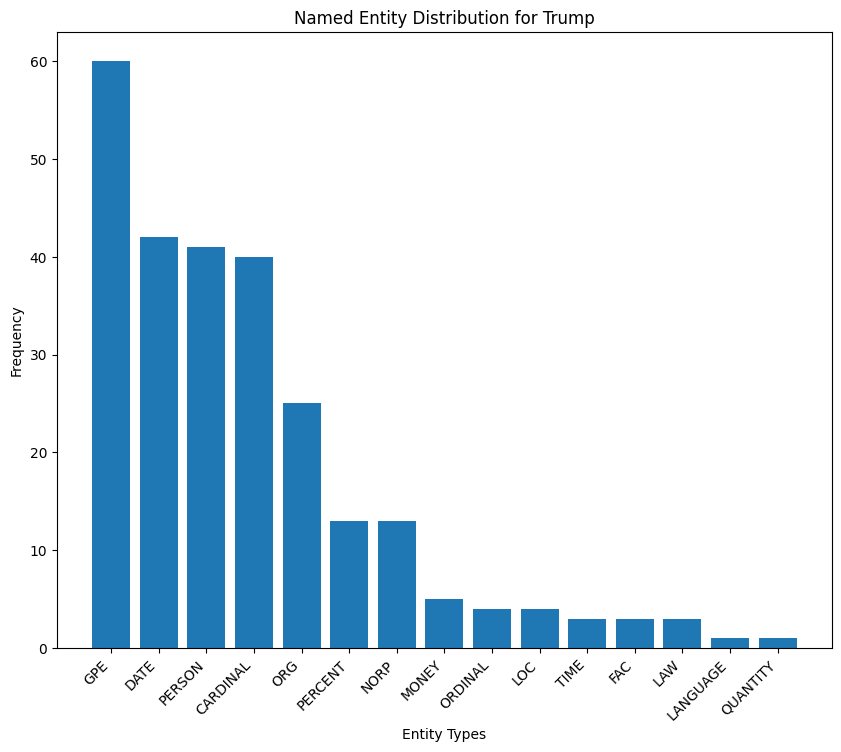

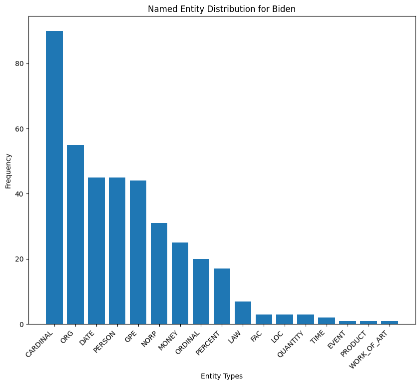

```python
# Extract only the text spoken by Trump and Biden themselves
trump_speech = trump_text[trump_text['speaker'] == 'President Trump']['text'].str.cat(sep=' ')
biden_speech = biden_text[biden_text['speaker'] == 'Joe Biden']['text'].str.cat(sep=' ')

# Function to extract entities and count them for each candidate
def extract_entities(text):
    doc = nlp(text)
    entities = [ent.label_ for ent in doc.ents]
    return Counter(entities)

# Extract entities for both candidates
trump_entities = extract_entities(trump_speech)
biden_entities = extract_entities(biden_speech)

def plot_entity_distribution(entities, candidate_name):
    # Sort entities by count
    sorted_entities = dict(sorted(entities.items(), key=lambda item: item[1], reverse=True))

    # Create the plot
    plt.figure(figsize=(10, 8))
    plt.bar(sorted_entities.keys(), sorted_entities.values())
    plt.title(f'Named Entity Distribution for {candidate_name}')
    plt.ylabel('Frequency')
    plt.xlabel('Entity Types')
    plt.xticks(rotation=45, ha="right")
    plt.show()

# Plot the entity distributions for Trump
plot_entity_distribution(trump_entities, "Trump")

# Plot the entity distributions for Biden
plot_entity_distribution(biden_entities, "Biden")
```

In the bar charts, for Trump, the most frequent named entity type was 'GPE' (countries, cities, etc.), followed by 'DATE' and 'PERSON'. This suggests a focus on geographical and temporal elements, as well as discussions involving specific individuals. The presence of 'CARDINAL' and 'ORG' also implies a quantitative aspect to his discussions and mentions of various organizations.

Biden's chart shows a higher frequency of 'CARDINAL' entities, indicating a strong emphasis on numbers and quantitative data in his speech. He also frequently mentioned 'ORG' and 'DATE', much like Trump. However, the 'GPE' count for Biden is lower compared to Trump, suggesting a possible difference in the geographical scope or focus of their discussions.

## 6. Generate a word cloud for Trump's town hall (use only Trump's words) and one for Biden's town hall (again, use only Biden's words). Compare and contrast the two word clouds.

Install a word cloud generating package like the one from https://github.com/amueller/word_cloud

```python
%pip install wordcloud
from wordcloud import WordCloud
```

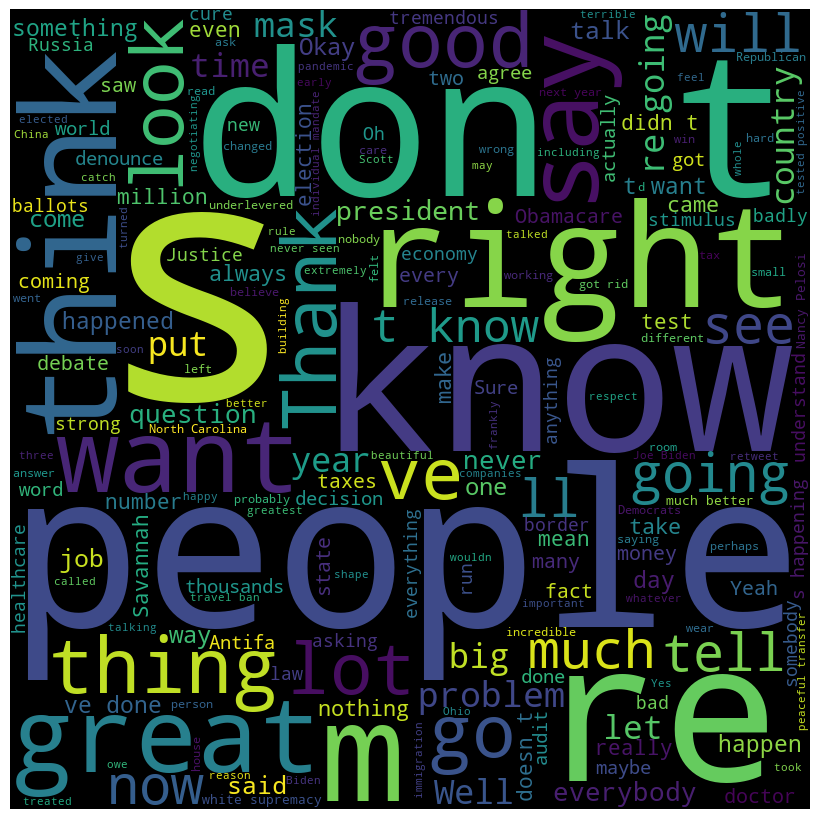

```
Trump's Word Cloud
```

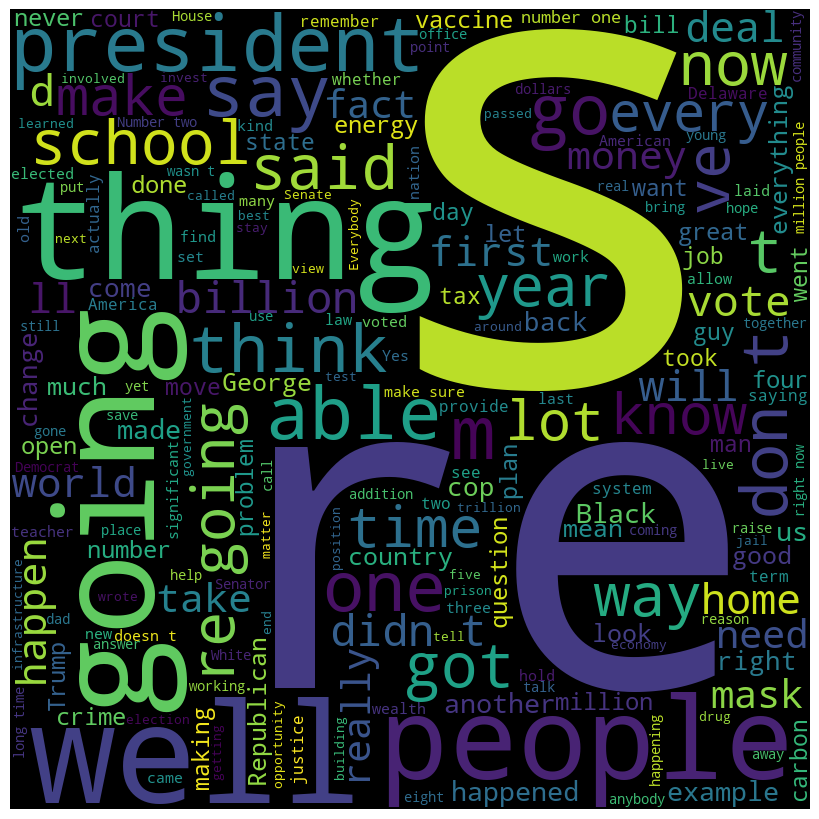

```
Biden's Word Cloud
```

```python
# Generate word cloud for Trump
trump_wordcloud = WordCloud(width = 800, height = 800,
                stopwords = None,
                min_font_size = 10).generate(trump_speech)

# Generate word cloud for Biden
biden_wordcloud = WordCloud(width = 800, height = 800,
                stopwords = None,
                min_font_size = 10).generate(biden_speech)


# Display the word clouds
plt.figure(figsize = (8, 8), facecolor = None)
plt.imshow(trump_wordcloud)
plt.axis("off")
plt.tight_layout(pad = 0)

plt.show()
print("Trump's Word Cloud")

plt.figure(figsize = (8, 8), facecolor = None)
plt.imshow(biden_wordcloud)
plt.axis("off")
plt.tight_layout(pad = 0)

plt.show()
print("Biden's Word Cloud")
```

Comparatively, Trump's cloud seems to emphasize action and subjective assertions, while Biden's places more emphasis on policy and governance. This could indicate Trump's focus on personal actions and decisions, whereas Biden may be more oriented towards policy implications and collective action.

## 7. Sentiment analysis of Trump vs. Biden in second debate

Note that you will want to review the video on Sentiment Analysis with NLTK and spaCy from the pre-recorded lectures.

Perform a sentiment analysis that compares the sentiment of the two candidates (Trump & Biden) in the second debate.

There are several ways to do this. In its simplest form, you could determine the sentiment for each utterance, the perform some mathematical summary (sum, mean, etc.) A slightly more elegant solution would involve tracking how sentiment changes over the course of the debate for each of the candidates. A further extension of your work might use the [pandas.DataFrame.rolling()](https://pandas.pydata.org/pandas-docs/stable/reference/api/pandas.DataFrame.rolling.html) method to calculate rolling averages, although using that function will probably require you to also learn about [time functions in pandas](https://pandas.pydata.org/pandas-docs/stable/user_guide/timeseries.html).

No matter what approach you choose, you should be sure to use visualizations in your answer. As always, provide an interpretation of your results, including any visualizations (i.e. don't just provide a visualization, explain what's interesting that you see in your visualizations).

```python
%pip install TextBlob
```

```
Downloading textblob-0.18.0.post0-py3-none-any.whl (626 kB)
   ━━━━━━━━━━━━━━━━━━━━━━━━━━━━━━━━━━━━━━━━ 626.3/626.3 kB 3.9 MB/s eta 0:00:0000:0100:01
```

[figure not shown]

```python
import numpy as np
from textblob import TextBlob

def get_polarity(text):
    return TextBlob(text).sentiment.polarity

def get_subjectivity(text):
    return TextBlob(text).sentiment.subjectivity

# Apply these functions to the text column of the dataframe
debate2_transcript['Polarity'] = debate2_transcript['text'].apply(get_polarity)
debate2_transcript['Subjectivity'] = debate2_transcript['text'].apply(get_subjectivity)

# Now, we will separate the data for each candidate
trump_debate2 = debate2_transcript[debate2_transcript['speaker'] == 'Donald Trump']
biden_debate2 = debate2_transcript[debate2_transcript['speaker'] == 'Joe Biden']

# Let's calculate the rolling average of the sentiment polarity over the course of the debate
trump_debate2['Rolling_Polarity'] = trump_debate2['Polarity'].rolling(10,min_periods=1).mean()
biden_debate2['Rolling_Polarity'] = biden_debate2['Polarity'].rolling(10,min_periods=1).mean()

# Plotting the sentiment over time for each candidate
plt.figure(figsize=(14, 6))
plt.plot(trump_debate2['minute'], trump_debate2['Rolling_Polarity'], label='Trump')
plt.plot(biden_debate2['minute'], biden_debate2['Rolling_Polarity'], label='Biden')
plt.title('Rolling Average Sentiment Polarity During the 2nd Presidential Debate')
plt.xlabel('Time (minutes)')
plt.ylabel('Sentiment Polarity')
plt.legend()
plt.show()
```

Both candidates exhibit fluctuations in sentiment polarity throughout the debate. This volatility could be a reflection of the varying topics discussed, with some topics eliciting more positive or negative language than others.Both candidates seem to range from mildly positive to mildly negative in sentiment, with no extreme values evident. This might indicate a moderated choice of language during the debate.

There are periods where one candidate's sentiment polarity is higher than the other's, which might suggest a more positive tone being employed by that candidate at that time. Conversely, when the lines dip below the zero mark, it indicates a more negative sentiment.Besides, there are multiple points where the lines intersect. These could be moments where the sentiment polarity of both candidates is similar, potentially due to agreement on an issue or a shift in the debate's focus towards a neutral or contentious topic.

The final part of the graph (towards the right end) may show how each candidate concluded their participation in the debate. It could be insightful to see if the sentiment ended on a positive or negative note.

# Please submit your notebook in .IPYNB and .HTML formats

We **strongly** suggest running all cells from top to bottom before you submit your notebook.